# FIFA soccer data 2019

Jeel Bhalodia, Saurav Kumar, Silke Meiner

Soccer may be a game to some. It reflects society and can be taken seriously. We present three cases.

1. / In chapter 1 we investigate the distribution of wealth within European clubs. We find that wealth is not evenly shared between clubs. A club with players of higher values is often seen in a leading final position in its league.
2. / In chapter 2 we follow the migration of players from poor countries to rich. Brasil takes a special role as a country most unable to feed its talented players into its own clubs.
3. / In chapter 3 we evaluate players performance on field positions and compare teams wrt their players performance. We present convincing visualisations indicating that a clubs final position in its league is related to its players performance in the field positions. This seems to hold true across European premier leagues.

```r
library(ggplot2)
```

# Distribution of wealth in Bundesliga

At the German premier league called Bundesliga, wealth is distributed unevenly between clubs.

We show a circles packaging where the size of a circle associated with a club corresponds to the cumulated value of its players. Large circles represent rich clubs. Additional information is put in the color of the circles: Dark colours corresponds to a final placement at the top of the league, whereas light colours correspond to a placement at the bottom of the league.

```r
library(packcircles)

# read data
soccer.1 <- read.csv("soccer-preprocessed-01.csv")
final.placement <- read.csv("abschlusstabelle.csv") %>%
  select(Tabellenplatz, club)
```

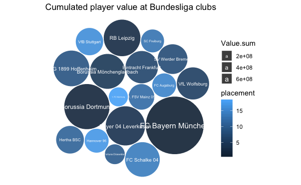

```r
## clubs from bundesliga
BL_Clubs <- final.placement$club
value.df <- filter(soccer.1, Club %in% BL_Clubs) %>%
  group_by(Club) %>%
  summarise(Value.sum=sum(Value)) %>%
  data.frame()
value.df <- merge(value.df , final.placement, by.x= 'Club', by.y='club')

packing <- circleProgressiveLayout(value.df$Value.sum, sizetype ='area')

# add packing information to the data frame
value.df <- cbind(value.df, packing)

npoints<-50
dat.gg <- circleLayoutVertices(packing, npoints=npoints)
dat.gg <- cbind(dat.gg, rep(value.df$Tabellenplatz,each=npoints+1))
names(dat.gg)[4] <- 'placement'

# Make the plot
p <- ggplot() +
  ggtitle("Cumulated player value at Bundesliga clubs") +

  # Make the bubbles
  geom_polygon(data = dat.gg, show.legend = TRUE , aes(x, y, group = id, fill = placement), colour = "white", alpha = 0.9) +

  # Add text in the center of each bubble + control its size
  geom_text(data = value.df, colour = "white",  aes(x, y, size=Value.sum, label = Club)) +
  scale_size_continuous(range = c(1,4)) +

  # General theme:
  theme_void() +
  theme(legend.position="right") +
  coord_equal()

show(p)
```

The visualisation implies that clubs with a higher cumulated value of its players placed higher and were more successful.

To investigate this further we would visualize the value of a club as bar charts, ordering clubs as in heir final placement. Also a regression could be more exact.

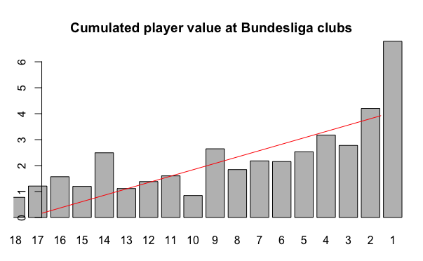

```r
#par(mfrow=c(1,1), mar=c(2,2,2,2)+0.1)
#bp <- barplot(value.df$Value.sum/1e+08, width=rep(15,18), main="Value of all players #for each club - Bundesliga", horiz=TRUE, xlim=c(0,7))
#text(y=bp, x=rep(0.05,18), labels=value.3$Club, adj=0, cex=1)
#legend('bottomright', c('Values in BN €'))

par(mfrow=c(1,1), mar=c(2,2,2,2)+0.1 , oma=c(1,1,1,1))
bp <- barplot(value.df$Value.sum / 1e+08 ~ value.df$Tabellenplatz, xlim = rev(range(2:19)) , main="Cumulated player value at Bundesliga clubs", axisnames=TRUE,ylab="BN Euro")
lm.obj<- lm(value.df$Value.sum / 1e+08 ~ value.df$Tabellenplatz)
#lm.obj$coeff
abline(lm.obj$coeff, col='red')
```

Room for improvement: 1. The bars should begin at the origin with x=0 not x=-1.5 2. colouring should be the same as in the plot above, so make it a ggplot. 3. a legend is needed to see which bar corresponds to which club. So one can compare the vague impression from the circles plot to the exact information in the barchart.